# FP2 Visualization

2023-09-27

```r
station <- c("Conservatory–Central Park Drive", "Conservatory–Central Park Drive", "Snelling Ave", "Snelling Ave","Lake St - Midtown", "Lake St - Midtown","Sierra Madre Villa","Sierra Madre Villa", "NoMa–Gallaudet U", "NoMa–Gallaudet U"  )
urbanArea <- c("Chicago", "Chicago","Saint Paul", "Saint Paul", "Minneapolis", "Minneapolis","Los Angeles", "Los Angeles", "Washington DC", "Washington DC")
cityNeighborhood <- c("East Garfield Park", "East Garfield Park", "Hamline-Midway", "Hamline-Midway", "Powderhorn",  "Powderhorn", "Pasadena", "Pasadena", "NOMA", "NOMA")
yearCreated <- c(2001, 2001, 2014,2014, 2004, 2004, 2003, 2003, 2007, 2007)
percentWhite <- c(1.13, 3.81, 69.93, 61.38, 42.03, 39.53, 50.43, 39.90, 10.53, 48.53)
beforeAfter <- c("Before Creation", "After Creation","Before Creation", "After Creation", "Before Creation", "After Creation", "Before Creation", "After Creation", "Before Creation", "After Creation")


transit <- data.frame(station,urbanArea,cityNeighborhood, yearCreated,percentWhite, beforeAfter)
```

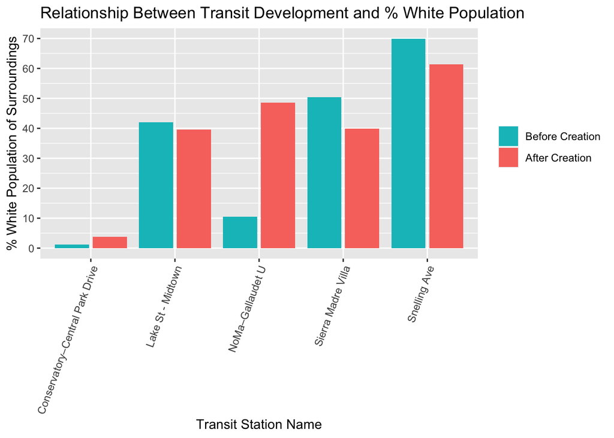

```r
transit %>%
  ggplot(aes(x=station, y=percentWhite, fill=beforeAfter)) +
  geom_col(position = position_dodge2(reverse = TRUE)) +
  guides(fill = guide_legend(reverse = TRUE))  +
  scale_x_discrete(guide = guide_axis(angle = 70)) +
  scale_y_continuous(breaks = round(seq(min(0), max(80), by = 10),1)) +
  theme(legend.title= element_blank()) +
  xlab("Transit Station Name") +
  ylab("% White Population of Surroundings") +
  ggtitle("Relationship Between Transit Development and % White Population")
```

**This visualization plays with the thought that transit-oriented development can bring upon gentrification. We consider a basic and narrow definition of gentrification, simply the percent of White population over time within a small area surrounding the station. This question was inspired by a discussion with one of our experts, Rachel Dungca of the Metro Transit. She said that analyzing the impact that stations have on the racial composition of neighborhoods is something they regularly do, though often find no impact. Nevertheless this was suggested as a potential research topic, as a correlation could be indicative of potential gentrification. This is an important question to answer, as we want to be sure that transit-oriented development is catering to all races and classes, and not pricing out those who can benefit from it the most.**

**On the x-axis we have five stations that were built within 2000-2015, with most of them being built in the early 2000s. One is from Chicago, two the Twin Cities, one in Los Angeles, and one in Washington D.C.. The blue bar references the white population of the surroundings in 2000, before the creation of the stations, and the red bar in 2020. This data was gathered from multiple censuses, and our “surrounding area” refers to the four nearest census block groups, totalling to a population of about 5,000. The intention of this visualization is to compare any changes between these values and attempt to find any patterns.**

**There is one trend that could potentially be noticed in this. Stations in neighborhoods that had a largely low white population in 2000 seems to increase by 2020, one by an immense magnitude. Meanwhile, stations that had a higher white population seems to decrease slightly. But overall, especially when looking at the region beyond the station, it seems that these changes are a result of something greater than transit-oriented development. Perhaps in Washington D.C. and Chicago these stations are a small part of greater gentrification, but I don’t believe we can say that TOD caused gentrification. This is in line with what our expert has found in the Twin Cities, and is overall a good sign of equity within the TOD process.**